# Bellabeat Case Study in R

Joy Cheng

2023-12-20

### Define Problem [Ask]

#### Background

Bellabeat, founded in 2013, is a high-tech company with a global presence, specializing in manufacturing health-focused smart products designed to enhance women’s health. The Bellabeat app is dedicated to gathering data on activity, sleep, stress, and reproductive health, empowering users to gain insights into their health and habits, thereby aiding them in making healthier choices. The app is integrated with Bellabeat’s wearable health tracking devices, including Leaf, Time, and Spring. In terms of marketing strategies, the company prioritizes digital channels such as media advertising, paid search, social media platforms, and YouTube. The co-founders of Bellabeat have requested an understanding of how users interact with smart devices and intend to leverage this understanding to make informed marketing decisions.

#### Business Objectives

1. Find out trends on how consumers uses non-Bellabeat smart-devices.
2. Provide high-level recommendations to help guide marketing strategy.

   Questions to address:
   - What are some trends in smart device usage? How do consumers use their device?
   - How could these trends apply to Bellabeat customers?
   - How could these trends help influence Bellabeat marketing strategy?

#### Key Stakeholders

- Urška Sršen and Sando Mur, cofounders and Chief Creative Officier of Bellabeat.
- Bellabeat’s marketing analytics team.

### Data Preparation [Prepare]

#### Data sources

Fitbit Fitness Tracker Data (“Fitabase Data 4.12.16-5.12.16”) downloaded from Mobius in Kaggle, an open-source data provided by a third party.

#### Data Integrity & Limitations

The dataset has been verified by Kaggle, receiving a usability and credibility score of 10.0, and it is under the CC0: Public Domain license, which means the creator has relinquished their rights to the work under copyright law. However, several limitations of the Fitbit dataset have been identified:

### Data Processing [Process]

#### Tool used for analysis

I will be using R to conduct my analysis, given its accessibility and the abundance of packages available for data cleaning, organization, calculation, and creating powerful data visualizations.

#### Data cleaning process

The data cleaning techniques utilized in this analysis include pre-checking datasets, identifying duplicates and missing values, merging tables, and verifying datatypes. Below is a brief breakdown of the steps taken to ensure data integrity before proceeding to the data transformation and analysis phase:

##### > Install packages

```r
install.packages("tidyverse")
install.packages("lubridate")
install.packages("here")
install.packages("skimr")
install.packages("janitor")
install.packages("ggpubr")
```

##### > Load packages

```r
library(tidyverse)
```

```r
library(lubridate)
library(dplyr)
library(ggplot2)
library(tidyr)
library(here)
library(skimr)
library(janitor)
library(ggpubr)
```

##### > Import data for the analysis

```r
daily_activity <- read.csv("/cloud/project/Fitabase_Data_2016/dailyActivity_merged.csv")

hourly_steps <- read.csv("/cloud/project/Fitabase_Data_2016/hourlySteps_merged.csv")

daily_intensity <- read.csv("/cloud/project/Fitabase_Data_2016/dailyIntensities_merged.csv")
hourly_intensity <- read.csv("/cloud/project/Fitabase_Data_2016/hourlyIntensities_merged.csv")


daily_calories <- read.csv("/cloud/project/Fitabase_Data_2016/dailyCalories_merged.csv")
hourly_calories <- read.csv("/cloud/project/Fitabase_Data_2016/hourlyCalories_merged.csv")

##daily_MET <- read.csv("/cloud/project/Fitabase_Data_2016/minuteMETsNarrow_merged.csv")

daily_sleep <- read.csv("/cloud/project/Fitabase_Data_2016/sleepDay_merged.csv")
##minute_sleep <- read.csv("/cloud/project/Fitabase_Data_2016/minuteSleep_merged.csv")

df_weight <- read.csv("/cloud/project/Fitabase_Data_2016/weightLogInfo_merged.csv")
```

##### > Count unique IDs in each dataset

```r
n_unique(daily_activity$Id)
```

```
## [1] 33
```

```r
n_unique(hourly_steps$Id)
```

```
## [1] 33
```

```r
n_unique(daily_intensity$Id)
```

```
## [1] 33
```

```r
n_unique(hourly_intensity$Id)
```

```
## [1] 33
```

```r
n_unique(daily_calories$Id)
```

```
## [1] 33
```

```r
n_unique(hourly_calories$Id)
```

```
## [1] 33
```

```r
##n_unique(daily_MET$Id)
n_unique(daily_sleep$Id)
```

```
## [1] 24
```

```r
##n_unique(minute_sleep$Id)
n_unique(df_weight$Id)
```

```
## [1] 8
```

From reviewing the count of unique IDs for each dataset, it is clear that there are more participants keeping track of their daily activity and calorie expenditure compare to those recording data on sleep and weight.

##### > Check missing values

```r
sum(is.na(daily_activity))
```

```
## [1] 0
```

```r
sum(is.na(hourly_steps))
```

```
## [1] 0
```

```r
sum(is.na(daily_intensity))
```

```
## [1] 0
```

```r
sum(is.na(hourly_intensity))
```

```
## [1] 0
```

```r
sum(is.na(daily_calories))
```

```
## [1] 0
```

```r
sum(is.na(hourly_calories))
```

```
## [1] 0
```

```r
##sum(is.na(daily_MET))
sum(is.na(daily_sleep))
```

```
## [1] 0
```

```r
##sum(is.na(minute_sleep))
sum(is.na(df_weight)) ##found 65 missing values
```

```
## [1] 65
```

##### > Count duplicates

```r
sum(duplicated(daily_activity))
```

```
## [1] 0
```

```r
sum(duplicated(hourly_steps))
```

```
## [1] 0
```

```r
sum(duplicated(daily_intensity))
```

```
## [1] 0
```

```r
sum(duplicated(hourly_intensity))
```

```
## [1] 0
```

```r
sum(duplicated(daily_calories))
```

```
## [1] 0
```

```r
sum(duplicated(hourly_calories))
```

```
## [1] 0
```

```r
##sum(duplicated(daily_MET))
sum(duplicated(daily_sleep)) ## found 3 duplicates
```

```
## [1] 3
```

```r
##sum(duplicated(minute_sleep))
sum(duplicated(df_weight))
```

```
## [1] 0
```

##### > Check & remove duplicate values

```r
##call out all duplicate rows
daily_sleep[duplicated(daily_sleep), ]
```

```
##             Id              SleepDay TotalSleepRecords TotalMinutesAsleep
## 162 4388161847  5/5/2016 12:00:00 AM                 1                471
## 224 4702921684  5/7/2016 12:00:00 AM                 1                520
## 381 8378563200 4/25/2016 12:00:00 AM                 1                388
##     TotalTimeInBed
## 162            495
## 224            543
## 381            402
```

```r
##remove all duplicated and make a copy of the dataset
daily_sleep_cleaned <- daily_sleep[!duplicated(daily_sleep), ]

##check the total rows of the newly created dataset "daily_sleep_cleaned"
sum(duplicated(daily_sleep_cleaned))
```

```
## [1] 0
```

Considering that some datasets lack sufficient participants (size < 20) to be representative of the entire population, they may face sampling bias. Therefore, for this analysis, I will focus solely on the datasets related to Activity, Intensity, Calories, and Sleep, exploring patterns within them.

Next, I will proceed to the data exploration phase and transform the data where needed.

### Data Exploration & Viz [Analyze & Share]

##### > Transform data

First, I noticed that the format of the datetime values across tables are inconsistent, so I will need to convert all datetime values to the same format (yyyy-mm-dd) and split the values into “Date” and “Time”. This way, it will be easier for me to examine and merge tables later on.

```r
df_sleep <- daily_sleep_cleaned %>%
  mutate(SleepDay = mdy_hms(SleepDay),   #parse date and time
         SleepDate = as_date(SleepDay),  #extract date
         Time = format(SleepDay, format = "%H:%M:%S"), #extract time
         SleepDay = NULL) %>%            #remove the original SleepDay column
  select(Id, SleepDate, Time, everything()) #reorder columns

glimpse(df_sleep) #check if successfully converted values to date type.
```

```
## Rows: 410
## Columns: 6
## $ Id                 <dbl> 1503960366, 1503960366, 1503960366, 1503960366, 150…
## $ SleepDate          <date> 2016-04-12, 2016-04-13, 2016-04-15, 2016-04-16, 20…
## $ Time               <chr> "00:00:00", "00:00:00", "00:00:00", "00:00:00", "00…
## $ TotalSleepRecords  <int> 1, 2, 1, 2, 1, 1, 1, 1, 1, 1, 1, 1, 1, 1, 1, 1, 1, …
## $ TotalMinutesAsleep <int> 327, 384, 412, 340, 700, 304, 360, 325, 361, 430, 2…
## $ TotalTimeInBed     <int> 346, 407, 442, 367, 712, 320, 377, 364, 384, 449, 3…
```

Next, do the same with “ActivityDate” in daily_activity table; convert column values to datetime format and split into Date and Time in separate columns for merging.

```r
df_daily <- daily_activity %>%
  mutate(ActivityDate = as_date(ActivityDate, format= '%m/%d/%Y')) %>% #convert to date format
  left_join(df_sleep, by=c('Id', 'ActivityDate'='SleepDate')) %>% #merge by matching Id and ActivityDate
  mutate(Weekday = wday(ActivityDate, label=TRUE, abbr=FALSE)) %>%  #find the day of week by date
  select(Id, ActivityDate, Time, Weekday, everything()) #reorder columns

str(df_daily)
```

```
## 'data.frame':    940 obs. of  20 variables:
##  $ Id                      : num  1.5e+09 1.5e+09 1.5e+09 1.5e+09 1.5e+09 ...
##  $ ActivityDate            : Date, format: "2016-04-12" "2016-04-13" ...
##  $ Time                    : chr  "00:00:00" "00:00:00" NA "00:00:00" ...
##  $ Weekday                 : Ord.factor w/ 7 levels "Sunday"<"Monday"<..: 3 4 5 6 7 1 2 3 4 5 ...
##  $ TotalSteps              : int  13162 10735 10460 9762 12669 9705 13019 15506 10544 9819 ...
##  $ TotalDistance           : num  8.5 6.97 6.74 6.28 8.16 ...
##  $ TrackerDistance         : num  8.5 6.97 6.74 6.28 8.16 ...
##  $ LoggedActivitiesDistance: num  0 0 0 0 0 0 0 0 0 0 ...
##  $ VeryActiveDistance      : num  1.88 1.57 2.44 2.14 2.71 ...
##  $ ModeratelyActiveDistance: num  0.55 0.69 0.4 1.26 0.41 ...
##  $ LightActiveDistance     : num  6.06 4.71 3.91 2.83 5.04 ...
##  $ SedentaryActiveDistance : num  0 0 0 0 0 0 0 0 0 0 ...
##  $ VeryActiveMinutes       : int  25 21 30 29 36 38 42 50 28 19 ...
##  $ FairlyActiveMinutes     : int  13 19 11 34 10 20 16 31 12 8 ...
##  $ LightlyActiveMinutes    : int  328 217 181 209 221 164 233 264 205 211 ...
##  $ SedentaryMinutes        : int  728 776 1218 726 773 539 1149 775 818 838 ...
##  $ Calories                : int  1985 1797 1776 1745 1863 1728 1921 2035 1786 1775 ...
##  $ TotalSleepRecords       : int  1 2 NA 1 2 1 NA 1 1 1 ...
##  $ TotalMinutesAsleep      : int  327 384 NA 412 340 700 NA 304 360 325 ...
##  $ TotalTimeInBed          : int  346 407 NA 442 367 712 NA 320 377 364 ...
```

##### > Merge dataset

Then, create a new hourly dataset that stores all hourly tables by merging them into one (intensity, steps, calories):

```r
df_hourly <- hourly_intensity %>%
  inner_join(hourly_steps, by=c("Id", "ActivityHour" )) %>%
  inner_join(hourly_calories, by=c("Id", "ActivityHour" )) %>%
  mutate(ActivityHour = mdy_hms(ActivityHour),   #parse date and time
         ActivityDate = as_date(ActivityHour),  #extract date
         Hour = format(ActivityHour, format = "%H:%M:%S"),
         ActivityHour = NULL,
         Weekday = wday(ActivityDate, label=TRUE, abbr=FALSE)) %>%
  select(Id, Weekday, ActivityDate, Hour, everything())

glimpse(df_hourly)
```

```
## Rows: 22,099
## Columns: 8
## $ Id               <dbl> 1503960366, 1503960366, 1503960366, 1503960366, 15039…
## $ Weekday          <ord> Tuesday, Tuesday, Tuesday, Tuesday, Tuesday, Tuesday,…
## $ ActivityDate     <date> 2016-04-12, 2016-04-12, 2016-04-12, 2016-04-12, 2016…
## $ Hour             <chr> "00:00:00", "01:00:00", "02:00:00", "03:00:00", "04:0…
## $ TotalIntensity   <int> 20, 8, 7, 0, 0, 0, 0, 0, 13, 30, 29, 12, 11, 6, 36, 5…
## $ AverageIntensity <dbl> 0.333333, 0.133333, 0.116667, 0.000000, 0.000000, 0.0…
## $ StepTotal        <int> 373, 160, 151, 0, 0, 0, 0, 0, 250, 1864, 676, 360, 25…
## $ Calories         <int> 81, 61, 59, 47, 48, 48, 48, 47, 68, 141, 99, 76, 73, …
```

After completing the cleaning and reformatting of the required datasets, I moved on to examining the summary of the `df_daily` dataset to gain an overview of each variable and check for outliers.

##### > Summarize dataset

```r
df_daily %>%
  #adding new column to calculate sleep efficiency
  mutate(SleepEfficiency = (TotalMinutesAsleep/TotalTimeInBed)*100) %>%
  #select only the variables interested to calculate summary
  select(TotalSteps, TotalDistance, TrackerDistance,
         LoggedActivitiesDistance, VeryActiveDistance,
         ModeratelyActiveDistance, LightActiveDistance,
         SedentaryActiveDistance, VeryActiveMinutes,
         FairlyActiveMinutes, LightlyActiveMinutes,
         SedentaryMinutes, Calories, TotalSleepRecords,
         TotalMinutesAsleep, TotalTimeInBed, SleepEfficiency) %>%
  drop_na() %>%
  summary()
```

```
##    TotalSteps    TotalDistance    TrackerDistance  LoggedActivitiesDistance
##  Min.   :   17   Min.   : 0.010   Min.   : 0.010   Min.   :0.0000
##  1st Qu.: 5189   1st Qu.: 3.592   1st Qu.: 3.592   1st Qu.:0.0000
##  Median : 8913   Median : 6.270   Median : 6.270   Median :0.0000
##  Mean   : 8515   Mean   : 6.012   Mean   : 6.007   Mean   :0.1089
##  3rd Qu.:11370   3rd Qu.: 8.005   3rd Qu.: 7.950   3rd Qu.:0.0000
##  Max.   :22770   Max.   :17.540   Max.   :17.540   Max.   :4.0817
##  VeryActiveDistance ModeratelyActiveDistance LightActiveDistance
##  Min.   : 0.000     Min.   :0.0000           Min.   :0.010
##  1st Qu.: 0.000     1st Qu.:0.0000           1st Qu.:2.540
##  Median : 0.570     Median :0.4200           Median :3.665
##  Mean   : 1.446     Mean   :0.7439           Mean   :3.791
##  3rd Qu.: 2.360     3rd Qu.:1.0375           3rd Qu.:4.918
##  Max.   :12.540     Max.   :6.4800           Max.   :9.480
##  SedentaryActiveDistance VeryActiveMinutes FairlyActiveMinutes
##  Min.   :0.0000000       Min.   :  0.00    Min.   :  0.00
##  1st Qu.:0.0000000       1st Qu.:  0.00    1st Qu.:  0.00
##  Median :0.0000000       Median :  9.00    Median : 11.00
##  Mean   :0.0009268       Mean   : 25.05    Mean   : 17.92
##  3rd Qu.:0.0000000       3rd Qu.: 38.00    3rd Qu.: 26.75
##  Max.   :0.1100000       Max.   :210.00    Max.   :143.00
##  LightlyActiveMinutes SedentaryMinutes    Calories    TotalSleepRecords
##  Min.   :  2.0        Min.   :   0.0   Min.   : 257   Min.   :1.00
##  1st Qu.:158.0        1st Qu.: 631.2   1st Qu.:1841   1st Qu.:1.00
##  Median :208.0        Median : 717.0   Median :2207   Median :1.00
##  Mean   :216.5        Mean   : 712.1   Mean   :2389   Mean   :1.12
##  3rd Qu.:263.0        3rd Qu.: 782.8   3rd Qu.:2920   3rd Qu.:1.00
##  Max.   :518.0        Max.   :1265.0   Max.   :4900   Max.   :3.00
##  TotalMinutesAsleep TotalTimeInBed  SleepEfficiency
##  Min.   : 58.0      Min.   : 61.0   Min.   : 49.84
##  1st Qu.:361.0      1st Qu.:403.8   1st Qu.: 91.18
##  Median :432.5      Median :463.0   Median : 94.26
##  Mean   :419.2      Mean   :458.5   Mean   : 91.65
##  3rd Qu.:490.0      3rd Qu.:526.0   3rd Qu.: 96.06
##  Max.   :796.0      Max.   :961.0   Max.   :100.00
```

**Key findings from this summary:**

Next, I decided to delve deeper and extract more information by performing statistical analyses and creating visualizations, aiming to uncover further insights into user behaviors and reveal underlying patterns.

#### Explore user behavior patterns

1. Average calories burned by hour.
2. Average steps during the week.
3. Average activity intensity in a day vs. in a week.
4. Average time spent in bed and asleep by day.
5. Usage frequency by daily logs.

##### >> User behavior #1 - Average calories burned by day and hour.

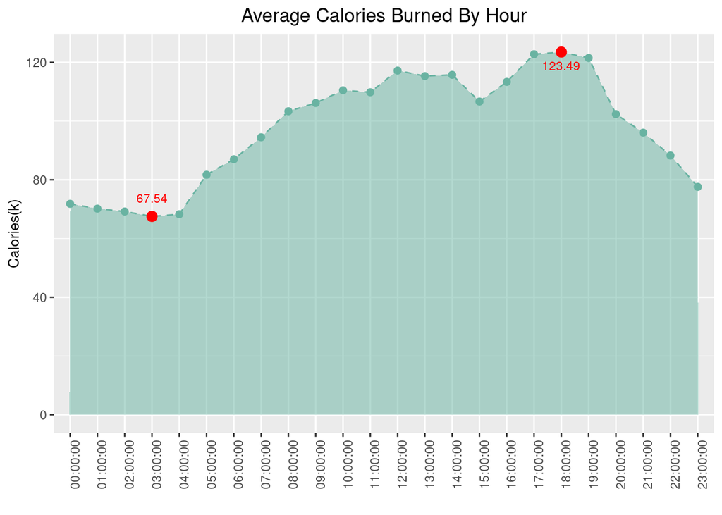

```r
#calculate the average calories burned for each unique day and hour combination,
#as well as the average for each hour.
avg_calories_by_hour <- df_hourly %>%
  group_by(Hour) %>%
  summarize(avg_calories_burned = mean(Calories), .groups='drop')

#assign order to Hour
avg_calories_by_hour$Hour <- factor(avg_calories_by_hour$Hour, levels=c("00:00:00","01:00:00","02:00:00","03:00:00","04:00:00","05:00:00","06:00:00","07:00:00","08:00:00","09:00:00","10:00:00","11:00:00","12:00:00","13:00:00","14:00:00","15:00:00","16:00:00","17:00:00","18:00:00","19:00:00","20:00:00","21:00:00","22:00:00","23:00:00"))

#get the index of the highest & lowest point of average calories
highest_calories_index <- which.max(avg_calories_by_hour$avg_calories_burned)
lowest_calories_index <- which.min(avg_calories_by_hour$avg_calories_burned)

#plot an area chart
ggplot(avg_calories_by_hour, aes(x=Hour, y=avg_calories_burned, group=1)) +
  geom_area(fill = "#69b3a2", linetype="dashed", color = "#69b3a2", alpha = 0.5) +
  geom_point(shape=21, color= "#69b3a2", fill="#69b3a2", size=2) +
  labs(title="Average Calories Burned By Hour", x="", y="Calories(k)" ) +
  theme(axis.text.x = element_text(angle=90),
        plot.title = element_text(hjust=0.5),
        axis.title = element_text(size=10)) +
  ## add numbers to the highest and lowest point
  geom_text(data = avg_calories_by_hour[highest_calories_index, ],
            aes(x = Hour, y = avg_calories_burned, label = sprintf("%.2f", avg_calories_burned)),
            color="red", size=3, vjust=2) +
  geom_text(data = avg_calories_by_hour[lowest_calories_index, ],
            aes(x = Hour, y = avg_calories_burned, label = sprintf("%.2f", avg_calories_burned)),
            color="red", size=3, vjust=-1.5) +
  #add annotations
  annotate("point", x = avg_calories_by_hour$Hour[highest_calories_index],
           y = avg_calories_by_hour$avg_calories_burned[highest_calories_index],
           color = "red", size = 3) +
  annotate("point", x = avg_calories_by_hour$Hour[lowest_calories_index],
           y = avg_calories_by_hour$avg_calories_burned[lowest_calories_index],
           color = "red", size = 3)
```

—> This graph shows that users tend to be burning more calories from 5pm-7pm which is usually when people gets off work or could be having meals or going out. Midnight hours from 12am-4am which is most likely to be people’s sleeping time is when they tend to be burning less calories.

##### >> User behavior #2 - Average steps during the week.

```r
#calculate the average steps by hour
avg_steps_by_hour <- df_hourly %>%
  group_by(Weekday, Hour) %>%
  summarize(avg_steps = mean(StepTotal), .groups='drop')

#re-order weekdays from Mon-Sun
avg_steps_by_hour$Weekday <- ordered(avg_steps_by_hour$Weekday,levels=c("Monday", "Tuesday", "Wednesday","Thursday","Friday", "Saturday", "Sunday"))

head(avg_steps_by_hour)
```

```
## # A tibble: 6 × 3
##   Weekday Hour     avg_steps
##   <ord>   <chr>        <dbl>
## 1 Sunday  00:00:00     82.6
## 2 Sunday  01:00:00     52.7
## 3 Sunday  02:00:00     49.6
## 4 Sunday  03:00:00      4.79
## 5 Sunday  04:00:00      5.65
## 6 Sunday  05:00:00     16.7
```

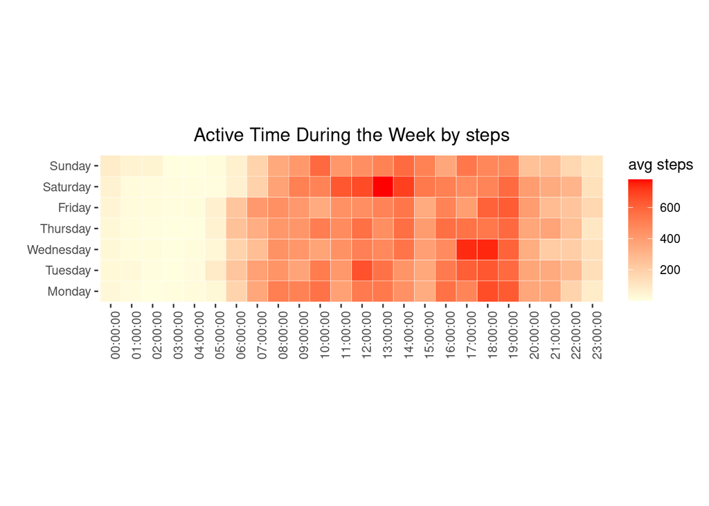

```r
#create heatmap to show users' active time during a week
ggplot(avg_steps_by_hour, aes(x=Hour, y=Weekday, fill=avg_steps)) +
  geom_tile(color= "white") +
  coord_fixed() +
  scale_fill_gradient(low="lightyellow", high="red") +
  labs(title= "Active Time During the Week by steps", x=" ", y=" ", fill="avg steps") +
  theme(axis.text.x= element_text(angle=90),
        plot.title = element_text(hjust = 0.5),
        panel.background= element_blank())
```

—> From this heatmap, we discovered that on weekdays, users usually start their day around 7am and are most active around 11am-1pm and 5pm-7pm which are usually their off-working hours. As for weekends, people usually start their day later around 9am, are most active around noon. Saturday seems to be generally more active throughout the day than Sunday.

##### >> User behavior #3 - Average activity intensity during the week.

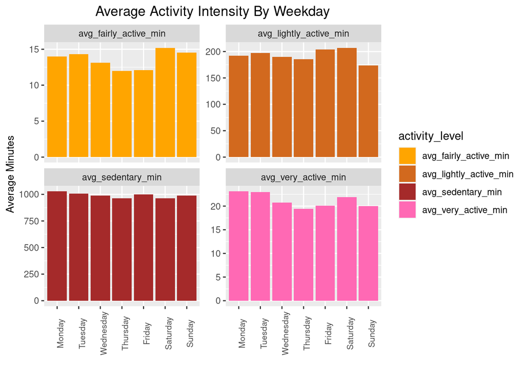

```r
#calculate the average for each activity intensity time by weekday
avg_intensity_by_week <- df_daily %>%
  group_by(Weekday) %>%
  summarize(avg_sedentary_min = mean(SedentaryMinutes),
            avg_lightly_active_min = mean(LightlyActiveMinutes),
            avg_fairly_active_min = mean(FairlyActiveMinutes),
            avg_very_active_min = mean(VeryActiveMinutes))

#re-order weekdays from Mon-Sun
avg_intensity_by_week$Weekday <- ordered(avg_intensity_by_week$Weekday,levels=c("Monday", "Tuesday", "Wednesday","Thursday","Friday", "Saturday", "Sunday"))

#reshape dataset to long format
avg_intensity_long <- tidyr::pivot_longer(avg_intensity_by_week,
                                          cols = starts_with("avg_"),
                                          names_to = "activity_level",
                                          values_to = "average_minutes")

#create a bar chart with facet_wrap
ggplot(avg_intensity_long, aes(x=Weekday, y=average_minutes, fill=activity_level)) +
  geom_bar(stat = "identity", position = "dodge") +
  facet_wrap(~ activity_level, scales = "free_y", ncol = 2) +
  scale_fill_manual(values = c("avg_sedentary_min" = "brown",
                                "avg_lightly_active_min" = "chocolate",
                                "avg_fairly_active_min" = "orange",
                                "avg_very_active_min" = "hotpink")) +
  labs(title = "Average Activity Intensity By Weekday", x = "", y = "Average Minutes") +
  theme(axis.text.x = element_text(angle = 90, size = 8),
        plot.title = element_text(hjust = 0.5),
        axis.title = element_text(size = 10))
```

—> It appears that Monday, Tuesday, and Saturday are the days when people are more likely to engage in intense physical activity for a longer duration. This observation may indicate variations in weekly routines or motivations for exercise on these specific days. However, the graphs also show that Monday tends to have the longest sedentary time of the week.

##### >> User behavior #4 - Average time spent in bed and asleep by day.

```r
#calculate the average time spent in bed by weekday
avg_bed_time <- df_sleep %>%
  group_by(Weekday = wday(SleepDate, label=TRUE, abbr=FALSE)) %>%
  summarize(avg_min_asleep=mean(TotalMinutesAsleep),
            avg_min_awake = mean(TotalTimeInBed-TotalMinutesAsleep))

#reshape to long format
avg_bed_time_long <- tidyr::gather(avg_bed_time, key="asleep_or_awake", value="avg_minutes", -Weekday)

#calculate percentage
avg_bed_time_long <- avg_bed_time_long %>%
  group_by(Weekday) %>%
  mutate(percentage=avg_minutes/sum(avg_minutes) * 100)

head(avg_bed_time_long)
```

```
## # A tibble: 6 × 4
## # Groups:   Weekday [6]
##   Weekday   asleep_or_awake avg_minutes percentage
##   <ord>     <chr>                 <dbl>      <dbl>
## 1 Sunday    avg_min_asleep         453.       89.9
## 2 Monday    avg_min_asleep         420.       91.7
## 3 Tuesday   avg_min_asleep         405.       91.3
## 4 Wednesday avg_min_asleep         435.       92.5
## 5 Thursday  avg_min_asleep         401.       92.3
## 6 Friday    avg_min_asleep         405.       91.1
```

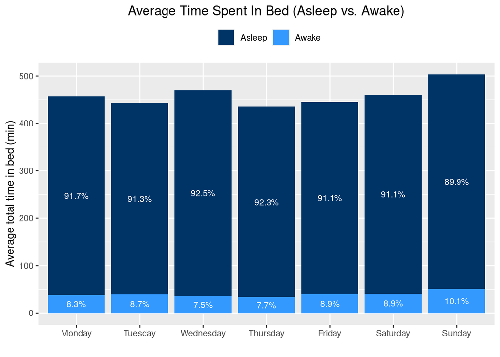

```r
#create a bar chart show the pattern of sleep time on a weekly basis
ggplot(avg_bed_time_long, aes(x=Weekday, y=avg_minutes, fill=asleep_or_awake)) +
  geom_bar(stat="identity") +
  scale_x_discrete(limits=c("Monday", "Tuesday", "Wednesday",
                            "Thursday","Friday","Saturday","Sunday")) +
  scale_fill_manual(values = c("#003366", "#3399FF"), labels = c("Asleep", "Awake")) +
  labs(title="Average Time Spent In Bed (Asleep vs. Awake)",
       x= "", y="Average total time in bed (min)", fill="") +
  geom_text(aes(label=sprintf("%.1f%%", percentage)),
            position=position_stack(vjust = 0.5), color="white", size = 3) +
  theme(legend.position="top", legend.box="horizontal",
        plot.title = element_text(hjust = 0.5))
```

—> Based on this stacked bar chart, we learned that the majority of users maintain a consistent sleep pattern throughout the week, with a high sleep efficiency (asleep/total time in bed) rate of 90% and above. However, Sunday shows a slightly lower rate. Additionally, it’s interestingly notable that users generally sleep longer on Wednesday and Sunday but less on Thursday and Tuesday.

##### >> User behavior #5 - Usage frequency in a month by daily logs.

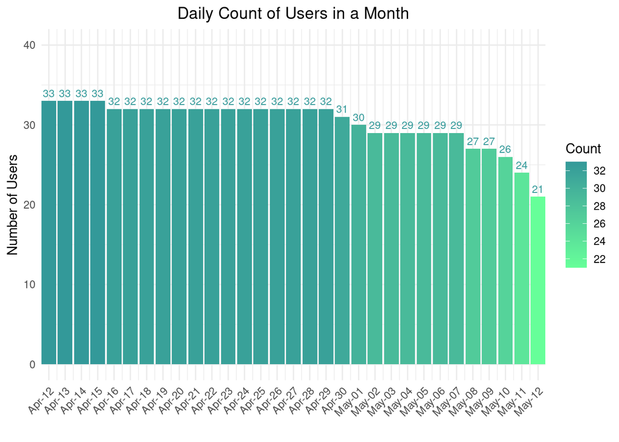

```r
#count how many users logged data each day by unique ids.
count_daily_users <- df_daily %>%
  group_by(ActivityDate) %>%
  summarize(users_num = n_distinct(Id))

ggplot(count_daily_users, aes(x=ActivityDate, y=users_num, fill=users_num)) +
  geom_col() +
  scale_fill_gradient(low= "#66FF99", high="#339999", name="Count",
                      breaks = seq(0, 40, by = 2),
                      labels = seq(0, 40, by = 2)) +
  geom_text(aes(label = users_num), vjust = -0.5, size = 3, color="#339999") +
  scale_x_date(date_labels = "%b-%d", date_breaks = "1 day", expand = c(0, 0)) +
  scale_y_continuous(limits=c(0,40)) +
  labs(title="Daily Count of Users in a Month", x=" ", y="Number of Users") +
  theme_minimal() +
  theme(axis.text.x = element_text(angle = 45, hjust = 1),
        plot.title = element_text(hjust = 0.5))
```

—> There is a gradual drop in the number of users about 2 weeks later and the decline continues to drop even more after the 3rd week. This could suggest a potential trend of decreasing user engagement or participation in a month.

#### Finding Correlation With Hypothesis

1. Does more total active minutes/steps means more calories burned?
2. Does active minutes/steps/calories lead to better sleep?
3. Does higher intensity minutes lead to quality sleep?

##### >> Test #1 - total active minutes/daily steps vs. calories

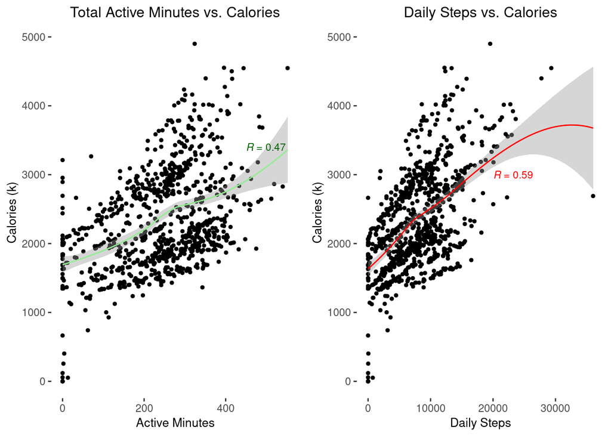

```r
#Add a new column to calculate the total active minutes.
df_daily<- df_daily %>%
  mutate(total_active_min =
         LightlyActiveMinutes + FairlyActiveMinutes + VeryActiveMinutes)


#Create a plot that shows active minutes vs. calories burned and daily Steps vs. calories burned.
p1 <- ggplot(df_daily, aes(x=total_active_min, y=Calories)) +
  geom_point(size=1) +
  ##scale_color_gradient(low="lightblue", high="darkblue") +
  geom_smooth(color="lightgreen", size=.5) +
  labs(title="Total Active Minutes vs. Calories", x="Active Minutes", y="Calories (k)") +
  stat_cor(method="pearson", aes(label = ..r.label..),
           label.x = 450, label.y = 3400, size = 3, color="darkgreen") +
  theme(panel.background = element_blank(),
        plot.title = element_text(size=12, hjust=0.5),
        axis.title = element_text(size=10))
p2 <- ggplot(df_daily, aes(x=TotalSteps, y=Calories)) +
  geom_point(size=1) +
  ##scale_color_gradient(low="lightblue", high="darkblue") +
  geom_smooth(color="red", size=.5) +
  labs(title="Daily Steps vs. Calories", x="Daily Steps", y="Calories (k)") +
  stat_cor(method="pearson", aes(label = ..r.label..),
           label.x = 20000, label.y = 3000, size = 3, color="red") +
  theme(panel.background = element_blank(),
        plot.title = element_text(size=12, hjust=0.5),
        axis.title = element_text(size=10))

ggarrange(p1, p2)
```

–> As one might have already expected, this graph shows a moderate positive correlation, indicating that the more active we are or the more steps we walk, the more calories we tend to burn in a day.

##### >> Test #2 - Daily steps vs. Sleep

See if having more total steps in a day will lead to more total asleep time using scatter plot.

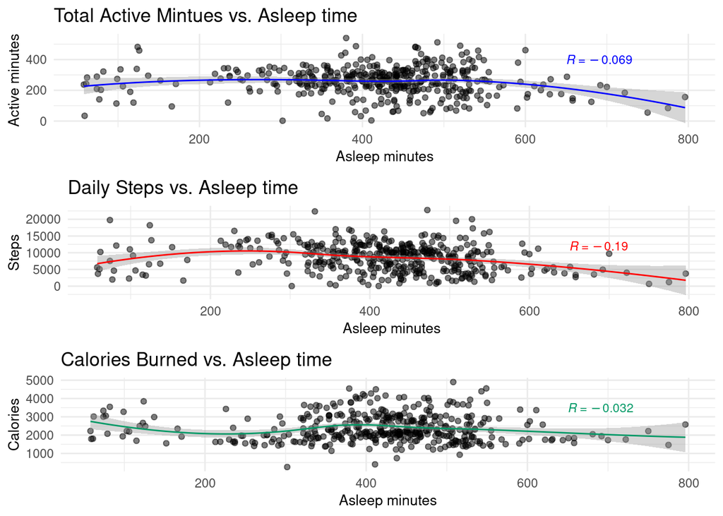

```r
p4 <- df_daily %>%
  drop_na() %>%
  ggplot(aes(x=TotalMinutesAsleep, y=total_active_min)) +
  geom_point(alpha=0.5) +
  geom_smooth(method = "loess", color="blue", size=0.5) +
  labs (title="Total Active Mintues vs. Asleep time", x="Asleep minutes", y="Active minutes" ) +
  stat_cor(method="pearson", aes(label = ..r.label..), label.x = 650, label.y = 400, size = 3, color="blue") +
  theme_minimal() +
  theme(axis.title = element_text(size=10))

p5 <- df_daily %>%
  drop_na() %>%
  ggplot(aes(x=TotalMinutesAsleep, y=TotalSteps)) +
  geom_point(alpha=0.5) +
  geom_smooth(method = "loess", color="red", size=0.5) +
  labs (title="Daily Steps vs. Asleep time", x="Asleep minutes", y="Steps" ) +
  stat_cor(method="pearson", aes(label = ..r.label..), label.x = 650, label.y = 12000, size = 3, color="red") +
  theme_minimal() +
  theme(axis.title = element_text(size=10))

p6 <- df_daily %>%
  drop_na() %>%
  ggplot(aes(x=TotalMinutesAsleep, y=Calories)) +
  geom_point(alpha=0.5) +
  geom_smooth(method = "loess", color="#009966", size=0.5) +
  labs (title="Calories Burned vs. Asleep time", x="Asleep minutes", y="Calories" ) +
  stat_cor(method="pearson", aes(label = ..r.label..), label.x = 650, label.y = 3500, size = 3, color="#009966") +
  theme_minimal() +
  theme(axis.title = element_text(size=10))

ggarrange(p4,p5,p6, ncol=1)
```

–> There is no correlation between activity, steps, and calorie expenditure with the amount of sleep. Therefore, we cannot conclude that having more steps, longer activity minutes, or burning more calories in the day will guarantee a better sleep for the night.

##### >> Test #3 - Intensity vs. Sleep

See if having more “very active” minutes will lead to better quality of sleep.

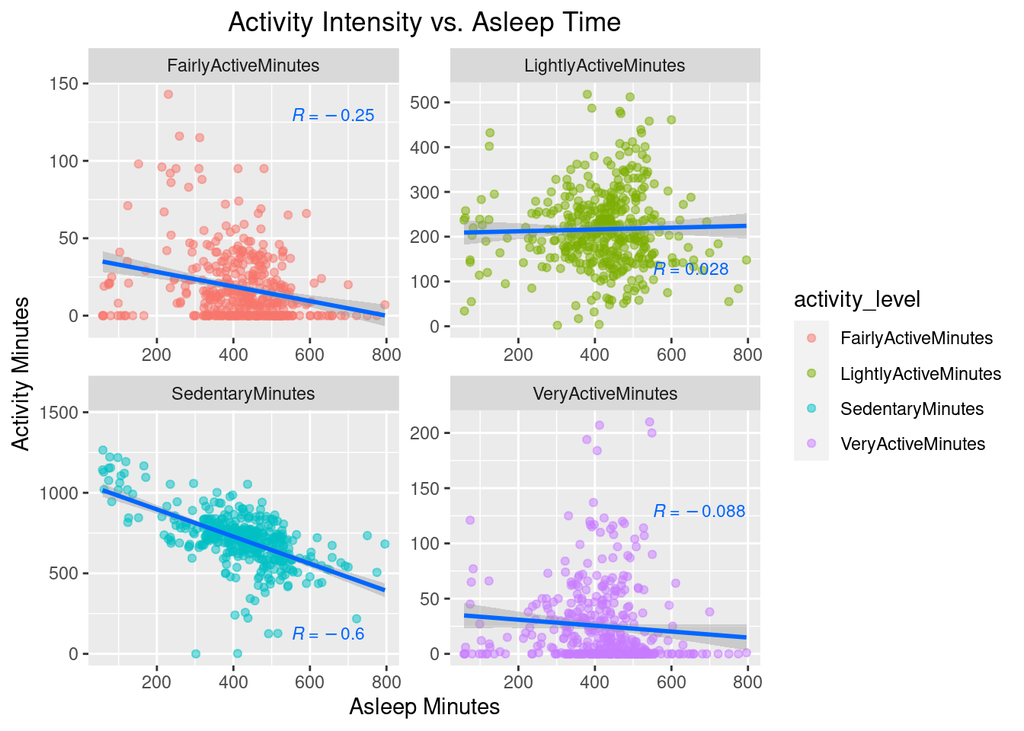

```r
#calculate the average for each activity intensity time by weekday
daily_intensity_and_sleep <- df_daily %>%
  select(Id, ActivityDate, SedentaryMinutes, LightlyActiveMinutes, FairlyActiveMinutes, VeryActiveMinutes, TotalMinutesAsleep)

#reshape dataset to long format
daily_intensity_and_sleep_long <-
  tidyr::pivot_longer(daily_intensity_and_sleep, cols = c(SedentaryMinutes, LightlyActiveMinutes, FairlyActiveMinutes, VeryActiveMinutes), names_to = "activity_level", values_to = "intensity_minutes")

#create a bar chart with facet_wrap
ggplot(daily_intensity_and_sleep_long, aes(x = TotalMinutesAsleep, y=intensity_minutes, color=activity_level)) +
  geom_point(alpha=0.5) +
  geom_smooth(method = "lm", color = "#0066FF") +
  facet_wrap(~activity_level, scales = "free") +
    labs(title = "Activity Intensity vs. Asleep Time",
       x = "Asleep Minutes", y = "Activity Minutes") +
  stat_cor(method = "pearson", aes(label = ..r.label..),
           label.x = 550, label.y = 130, size=3, color="#0066FF") +
  theme(plot.title = element_text(hjust=0.5))
```

—> While there is no significant relationship between active intensity with the amount of sleep, we do find a negative correlation line (R=-0.6) in the chart for sedentary time and sleep. This indicates that as sedentary time increases, sleep time tends to decrease.

### Conclusion & Recommendations [Act]

#### Marketing recommendations for BellaBeat’s App:

- **Promote Consistent Fitness**: Send reminders on days with lower activity levels, such as Wednesdays and Thursdays, or during prolonged sedentary time like working hours, encouraging users to stretch and take walks.
- **Enable Goal Setting**: Implement features allowing users to establish personal daily and long-term goals, such as achieving 10,000 steps per day, hitting weight loss targets, or ensuring eight hours of nightly sleep, to sustain motivation.
- **Educate Users and Provide Personalized Tips**: Promote the benefits of a healthy lifestyle by offering tailored workout plans and guidance based on users’ health status and goals. Utilize insightful content and visualizations in marketing campaigns to emphasize the significance of physical wellness for women’s health, inspiring them to explore and embrace healthier daily habits.
- **Implement Smart Alerts**: Integrate a smart auto-alert to remind users of prolonged device inactivity, boosting device wear time and engagement. For users seeking to enhance their sleep, include an auto-alert after 20 minutes in bed without falling asleep to encourage rest and reduce screen time for better sleep quality.
- **Customizable Notifications**: Enable users to adjust their notifications, selecting content and timing according to their preferences. This customization enhances user engagement and tailors the app experience to individual needs, fostering a more personalized and user-centric platform.
- **Implement an Interactive Reward System**: Incorporate external motivations by rewarding users with badges or medals for achieving goals, such as walking more than 10,000 steps a day. This helps to incentivizes users, increases device usage frequency and duration, and enhances app engagement.
- **Allow Invites and Sharing**: Establish an online social community where users can invite friends to share activity through the app and celebrate milestones together. Cultivate a supportive environment for users to exchange ideas, share achievements, and inspire one another in making healthy decisions.

**Note**: The findings and recommendations provided above are derived from the available data, acknowledging the identified limitations. Readers and stakeholders are encouraged to interpret these findings judiciously, taking into account the mentioned limitations, especially when making business decisions.